# Baixando dados de ocorrência e ambientais no R

Brunno F Oliveira

2024-11-05

Para este exercício, vamos baixar dados de ocorrencia uma espécie marinha de sua escolha, bem como baixar variáveis ambientais do oceano.

# Pacotes

```r
# funcao para instalar pacotes se ainda nao estao instalados
install_pack <- function(x){
  new.packages <- x[!(x %in% installed.packages()[,"Package"])]
  if(length(new.packages)) install.packages(new.packages)
}

# os de pacotes
pacotes <- c(
  "tidyverse",
  "rnaturalearth",
  "rnaturalearthdata",
  "nngeo",
  "sf",
  "tmap",
  "spocc",
  "CoordinateCleaner",
  "spThin",
  "mapview",
  "mapedit",
  "raster",
  "viridis",
  "usdm",
  "ENMTools",
  "geodata",
  "ade4",
  "robis",
  "here",
  "sdmpredictors"
)

# devtools::install_github("bio-oracle/biooracler")

# instale
install_pack(pacotes)

# carregue
for(i in pacotes){
  eval(bquote(library(.(i))))
}
```

[output not shown]

# Criar diretorios

Primeiro, vamos criar os diretórios onde nossos dados serão salvos.

```r
dir.create("03_dados")
dir.create("03_dados/01_ocorrencias")
dir.create("03_dados/02_variaveis")
```

# Ambiente terrestre

Primeiro vamos criar um shape file para a America do Sul

```r
li <- rnaturalearth::ne_countries(
  scale = 50,
  continent = "South America", returnclass = "sf") %>%
  sf::st_union(rnaturalearth::ne_countries(scale = 50,
                                           country = "France",
                                           returnclass = "sf")) %>%
  sf::st_crop(rnaturalearth::ne_countries(continent = "South America",
                                          returnclass = "sf")) %>%
  sf::st_union() %>%
  nngeo::st_remove_holes() %>%
  sf::st_as_sf()
li
```

```
Simple feature collection with 1 feature and 0 fields
Geometry type: MULTIPOLYGON
Dimension:     XY
Bounding box:  xmin: -81.33662 ymin: -55.8917 xmax: -34.80547 ymax: 12.43437
Geodetic CRS:  WGS 84
                               x
1 MULTIPOLYGON (((-64.58135 -...
```

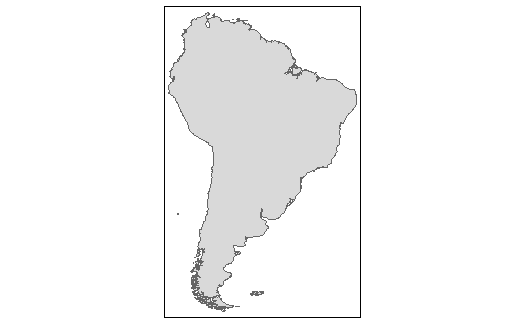

```r
tm_shape(li) +
  tm_polygons()
```

## Ocorrencia

Vamos baixar ocorrencias para a espécie *Marmosops incanus*.

[figure not shown]

```r
sp <- "Marmosops incanus"

# spocc - pode demorar um tempo...
occ_spocc <- spocc::occ(query = sp,
                        from = c("gbif", "inat", "vertnet", "idigbio", "ecoengine"),
                        has_coords = TRUE,
                        limit = 1e5)
occ_spocc
```

```
Searched: gbif, inat, vertnet, idigbio, ecoengine
Occurrences - Found: 706, Returned: 706
Search type: Scientific
  gbif: Marmosops incanus (279)
  inat: Marmosops incanus (21)
  vertnet: Marmosops incanus (216)
  idigbio: Marmosops incanus (190)

Note: spocc cannot estimate complete additional records found as none available for ebird
```

```r
# get data
occ_data <- spocc::occ2df(occ_spocc) %>%
  dplyr::mutate(species = sp,
                longitude = as.numeric(longitude),
                latitude = as.numeric(latitude),
                year = date %>% lubridate::year(),
                base = prov %>% stringr::str_to_lower()) %>%
  dplyr::select(name, species, longitude, latitude, year, base)

occ_data
```

| name | species | longitude | latitude | year | base |
| --- | --- | --- | --- | --- | --- |
| Marmosops incanus (Lund, 1840) | Marmosops incanus | -41.83179 | -20.480428 | 2024 | gbif |
| Marmosops incanus (Lund, 1840) | Marmosops incanus | -42.04230 | -20.962874 | 2023 | gbif |
| Marmosops incanus (Lund, 1840) | Marmosops incanus | -43.47129 | -19.997750 | 2021 | gbif |
| Marmosops incanus (Lund, 1840) | Marmosops incanus | -40.99210 | -20.474782 | 2019 | gbif |
| Marmosops incanus (Lund, 1840) | Marmosops incanus | -40.60050 | -19.937389 | 2018 | gbif |
| Marmosops incanus (Lund, 1840) | Marmosops incanus | -44.20246 | -23.143886 | 2017 | gbif |
| Marmosops incanus (Lund, 1840) | Marmosops incanus | -40.14198 | -19.004421 | 2014 | gbif |
| Marmosops incanus (Lund, 1840) | Marmosops incanus | -40.02319 | -19.280036 | 2014 | gbif |
| Marmosops incanus (Lund, 1840) | Marmosops incanus | -40.05427 | -19.291069 | 2013 | gbif |
| Marmosops incanus (Lund, 1840) | Marmosops incanus | -40.42030 | -20.264310 | 2012 | gbif |

[output cut: 696 more lines]

```r
# map
occ_data_vector <- occ_data %>%
  tidyr::drop_na(longitude, latitude) %>%
  dplyr::mutate(lon = longitude, lat = latitude) %>%
  dplyr::filter(lon >= -180, lon <= 180, lat >= -90, lat <= 90) %>%
  sf::st_as_sf(coords = c("lon", "lat"), crs = 4326)

occ_data_vector
```

```
Simple feature collection with 706 features and 6 fields
Geometry type: POINT
Dimension:     XY
Bounding box:  xmin: -74.58136 ymin: -24.33333 xmax: -39 ymax: 9.245353
Geodetic CRS:  WGS 84
```

|  | name | species | longitude | latitude | year | base | geometry |
| --- | --- | --- | --- | --- | --- | --- | --- |
| 1 | Marmosops incanus (Lund, 1840) | Marmosops incanus | -41.83179 | -20.480428 | 2024 | gbif |  |
| 2 | Marmosops incanus (Lund, 1840) | Marmosops incanus | -42.04230 | -20.962874 | 2023 | gbif |  |
| 3 | Marmosops incanus (Lund, 1840) | Marmosops incanus | -43.47129 | -19.997750 | 2021 | gbif |  |
| 4 | Marmosops incanus (Lund, 1840) | Marmosops incanus | -40.99210 | -20.474782 | 2019 | gbif |  |
| 5 | Marmosops incanus (Lund, 1840) | Marmosops incanus | -40.60050 | -19.937389 | 2018 | gbif |  |
| 6 | Marmosops incanus (Lund, 1840) | Marmosops incanus | -44.20246 | -23.143886 | 2017 | gbif |  |
| 7 | Marmosops incanus (Lund, 1840) | Marmosops incanus | -40.14198 | -19.004421 | 2014 | gbif |  |
| 8 | Marmosops incanus (Lund, 1840) | Marmosops incanus | -40.02319 | -19.280036 | 2014 | gbif |  |
| 9 | Marmosops incanus (Lund, 1840) | Marmosops incanus | -40.05427 | -19.291069 | 2013 | gbif |  |
| 10 | Marmosops incanus (Lund, 1840) | Marmosops incanus | -40.42030 | -20.264310 | 2012 | gbif |  |

[output cut: 696 more lines]

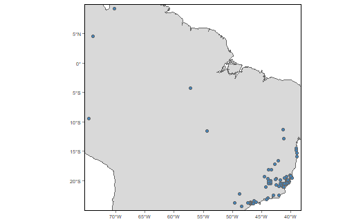

```r
tm_shape(li, bbox = occ_data_vector) +
  tm_polygons() +
  tm_shape(occ_data_vector) +
  tm_dots(size = .2, shape = 21, col = "steelblue") +
  tm_graticules(lines = FALSE)
```

### Spatial limit filter

```r
# crop to limit
occ_data_sptlim <- occ_data_vector %>%
  st_crop(li)
occ_data_sptlim
```

```
Simple feature collection with 706 features and 6 fields
Geometry type: POINT
Dimension:     XY
Bounding box:  xmin: -74.58136 ymin: -24.33333 xmax: -39 ymax: 9.245353
Geodetic CRS:  WGS 84
```

|  | name | species | longitude | latitude | year | base | geometry |
| --- | --- | --- | --- | --- | --- | --- | --- |
| 1 | Marmosops incanus (Lund, 1840) | Marmosops incanus | -41.83179 | -20.480428 | 2024 | gbif |  |
| 2 | Marmosops incanus (Lund, 1840) | Marmosops incanus | -42.04230 | -20.962874 | 2023 | gbif |  |
| 3 | Marmosops incanus (Lund, 1840) | Marmosops incanus | -43.47129 | -19.997750 | 2021 | gbif |  |
| 4 | Marmosops incanus (Lund, 1840) | Marmosops incanus | -40.99210 | -20.474782 | 2019 | gbif |  |
| 5 | Marmosops incanus (Lund, 1840) | Marmosops incanus | -40.60050 | -19.937389 | 2018 | gbif |  |
| 6 | Marmosops incanus (Lund, 1840) | Marmosops incanus | -44.20246 | -23.143886 | 2017 | gbif |  |
| 7 | Marmosops incanus (Lund, 1840) | Marmosops incanus | -40.14198 | -19.004421 | 2014 | gbif |  |
| 8 | Marmosops incanus (Lund, 1840) | Marmosops incanus | -40.02319 | -19.280036 | 2014 | gbif |  |
| 9 | Marmosops incanus (Lund, 1840) | Marmosops incanus | -40.05427 | -19.291069 | 2013 | gbif |  |
| 10 | Marmosops incanus (Lund, 1840) | Marmosops incanus | -40.42030 | -20.264310 | 2012 | gbif |  |

[output cut: 696 more lines]

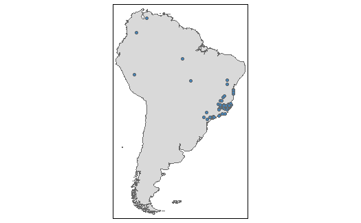

```r
# map
tm_shape(li) +
  tm_polygons() +
  tm_shape(occ_data_sptlim) +
  tm_dots(size = .2, shape = 21, col = "steelblue")
```

### Date filter

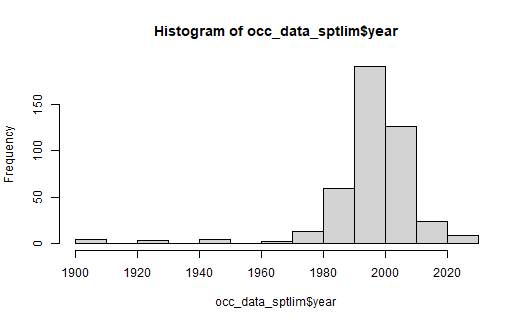

```r
# verify
hist(occ_data_sptlim$year)
```

```r
# year > 1970 and < 2021
occ_data_sptlim_date <- occ_data_sptlim %>%
  filter(year >= 1970)
occ_data_sptlim_date
```

```
Simple feature collection with 424 features and 6 fields
Geometry type: POINT
Dimension:     XY
Bounding box:  xmin: -74.58136 ymin: -24.33333 xmax: -39 ymax: 9.245353
Geodetic CRS:  WGS 84
```

|  | name | species | longitude | latitude | year | base | geometry |
| --- | --- | --- | --- | --- | --- | --- | --- |
| 1 | Marmosops incanus (Lund, 1840) | Marmosops incanus | -41.83179 | -20.480428 | 2024 | gbif |  |
| 2 | Marmosops incanus (Lund, 1840) | Marmosops incanus | -42.04230 | -20.962874 | 2023 | gbif |  |
| 3 | Marmosops incanus (Lund, 1840) | Marmosops incanus | -43.47129 | -19.997750 | 2021 | gbif |  |
| 4 | Marmosops incanus (Lund, 1840) | Marmosops incanus | -40.99210 | -20.474782 | 2019 | gbif |  |
| 5 | Marmosops incanus (Lund, 1840) | Marmosops incanus | -40.60050 | -19.937389 | 2018 | gbif |  |
| 6 | Marmosops incanus (Lund, 1840) | Marmosops incanus | -44.20246 | -23.143886 | 2017 | gbif |  |
| 7 | Marmosops incanus (Lund, 1840) | Marmosops incanus | -40.14198 | -19.004421 | 2014 | gbif |  |
| 8 | Marmosops incanus (Lund, 1840) | Marmosops incanus | -40.02319 | -19.280036 | 2014 | gbif |  |
| 9 | Marmosops incanus (Lund, 1840) | Marmosops incanus | -40.05427 | -19.291069 | 2013 | gbif |  |
| 10 | Marmosops incanus (Lund, 1840) | Marmosops incanus | -40.42030 | -20.264310 | 2012 | gbif |  |

[output cut: 414 more lines]

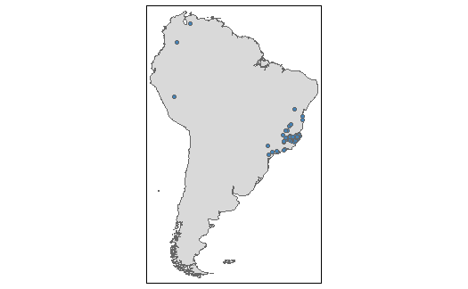

```r
# map
tm_shape(li) +
  tm_polygons() +
  tm_shape(occ_data_sptlim_date) +
  tm_dots(size = .2, shape = 21, col = "steelblue")
```

### Bias filter

```r
# flag data
occ_data_sptlim_date_bias <- CoordinateCleaner::clean_coordinates(
  x = sf::st_drop_geometry(occ_data_sptlim_date),
  species = "species",
  lon = "longitude",
  lat = "latitude",
  outliers_mtp = 2,
  value = "clean", # return the clean dataset
  tests = c("capitals", # radius around capitals
            "centroids", # radius around country and province centroids
            "duplicates", # records from one species with identical coordinates
            "equal", # equal coordinates
            "gbif", # radius around GBIF headquarters
            "institutions", # radius around biodiversity institutions
            "seas", # in the sea
            "urban", # within urban area
            "validity", # outside reference coordinate system
            "zeros" # plain zeros and lat = lon
  )) %>%
  tibble::as_tibble() %>%
  dplyr::mutate(lon = longitude, lat = latitude) %>%
  sf::st_as_sf(coords = c("lon", "lat"), crs = 4326)
```

```
Testing coordinate validity
Flagged 0 records.
Testing equal lat/lon
Flagged 0 records.
Testing zero coordinates
Flagged 0 records.
Testing country capitals
Flagged 0 records.
Testing country centroids
Flagged 0 records.
Testing sea coordinates
```

```
Flagged 0 records.
Testing urban areas
Downloading urban areas via rnaturalearth
```

```
Flagged 7 records.
Testing GBIF headquarters, flagging records around Copenhagen
Flagged 0 records.
Testing biodiversity institutions
Flagged 45 records.
Testing duplicates
Flagged 331 records.
Flagged 338 of 424 records, EQ = 0.8.
```

```r
occ_data_sptlim_date_bias
```

```
Simple feature collection with 86 features and 6 fields
Geometry type: POINT
Dimension:     XY
Bounding box:  xmin: -74.58136 ymin: -24.33333 xmax: -39 ymax: 9.245353
Geodetic CRS:  WGS 84
```

|  | name | species | longitude | latitude | year | base | geometry |
| --- | --- | --- | --- | --- | --- | --- | --- |
| 1 | Marmosops incanus (Lund, 1840) | Marmosops incanus | -41.83179 | -20.480428 | 2024 | gbif |  |
| 2 | Marmosops incanus (Lund, 1840) | Marmosops incanus | -42.04230 | -20.962874 | 2023 | gbif |  |
| 3 | Marmosops incanus (Lund, 1840) | Marmosops incanus | -43.47129 | -19.997750 | 2021 | gbif |  |
| 4 | Marmosops incanus (Lund, 1840) | Marmosops incanus | -40.99210 | -20.474782 | 2019 | gbif |  |
| 5 | Marmosops incanus (Lund, 1840) | Marmosops incanus | -40.60050 | -19.937389 | 2018 | gbif |  |
| 6 | Marmosops incanus (Lund, 1840) | Marmosops incanus | -44.20246 | -23.143886 | 2017 | gbif |  |
| 7 | Marmosops incanus (Lund, 1840) | Marmosops incanus | -40.14198 | -19.004421 | 2014 | gbif |  |
| 8 | Marmosops incanus (Lund, 1840) | Marmosops incanus | -40.02319 | -19.280036 | 2014 | gbif |  |
| 9 | Marmosops incanus (Lund, 1840) | Marmosops incanus | -40.05427 | -19.291069 | 2013 | gbif |  |
| 10 | Marmosops incanus (Lund, 1840) | Marmosops incanus | -40.42030 | -20.264310 | 2012 | gbif |  |

[output cut: 76 more lines]

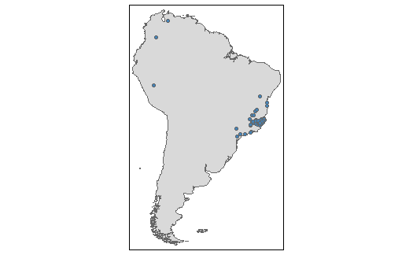

```r
# map
tm_shape(li) +
  tm_polygons() +
  tm_shape(occ_data_sptlim_date_bias) +
  tm_dots(size = .2, shape = 21, col = "steelblue")
```

### Spatial distance filter

```r
filter_thin <- spThin::thin(loc.data = occ_data_sptlim_date_bias,
                            lat.col = "latitude",
                            long.col = "longitude",
                            spec.col = "species",
                            thin.par = 50,
                            reps = 1,
                            write.files = FALSE,
                            write.log.file = FALSE,
                            locs.thinned.list.return = TRUE,
                            verbose = TRUE) %>%
  .[[1]] %>%
  tibble::as_tibble() %>%
  dplyr::rename_with(tolower) %>%
  dplyr::mutate(sptdist_filter = TRUE)
```

```
 Beginning Spatial Thinning.
 Script Started at: Wed Nov  6 11:45:46 2024
lat.long.thin.count
31
 1
[1] "Maximum number of records after thinning: 31"
[1] "Number of data.frames with max records: 1"
[1] "No files written for this run."
```

```r
filter_thin
```

| longitude | latitude | sptdist_filter |
| --- | --- | --- |
| -41.83179 | -20.480428 | TRUE |
| -43.86444 | -18.132778 | TRUE |
| -41.07461 | -19.508492 | TRUE |
| -40.52000 | -20.280000 | TRUE |
| -44.27844 | -21.053000 | TRUE |
| -47.41972 | -23.710000 | TRUE |
| -39.81369 | -19.543444 | TRUE |
| -42.65040 | -19.717150 | TRUE |
| -42.76706 | -17.133801 | TRUE |
| -39.00036 | -15.350464 | TRUE |

[output cut: 21 more lines]

```r
# join
occ_data_sptlim_date_bias_sptdist <- dplyr::left_join(
  x = occ_data_sptlim_date_bias,
  y = filter_thin,
  by = c("longitude", "latitude")) %>%
  filter(sptdist_filter)
occ_data_sptlim_date_bias_sptdist
```

```
Simple feature collection with 31 features and 7 fields
Geometry type: POINT
Dimension:     XY
Bounding box:  xmin: -74.58136 ymin: -24.33333 xmax: -39.00036 ymax: 9.245353
Geodetic CRS:  WGS 84
```

|  | name | species | longitude | latitude | year | base | geometry | sptdist_filter |
| --- | --- | --- | --- | --- | --- | --- | --- | --- |
| 1 | Marmosops incanus (Lund, 1840) | Marmosops incanus | -41.83179 | -20.480428 | 2024 | gbif |  | TRUE |
| 2 | Marmosops incanus (Lund, 1840) | Marmosops incanus | -43.86444 | -18.132778 | 2011 | gbif |  | TRUE |
| 3 | Marmosops incanus (Lund, 1840) | Marmosops incanus | -41.07461 | -19.508492 | 2011 | gbif |  | TRUE |
| 4 | BOLD:AAD2962 | Marmosops incanus | -40.52000 | -20.280000 | 2007 | gbif |  | TRUE |
| 5 | Marmosops incanus (Lund, 1840) | Marmosops incanus | -44.27844 | -21.053000 | 2003 | gbif |  | TRUE |
| 6 | Marmosops incanus (Lund, 1840) | Marmosops incanus | -47.41972 | -23.710000 | 2002 | gbif |  | TRUE |
| 7 | Marmosops incanus (Lund, 1840) | Marmosops incanus | -39.81369 | -19.543444 | 2000 | gbif |  | TRUE |
| 8 | Marmosops incanus (Lund, 1840) | Marmosops incanus | -42.65040 | -19.717150 | 1996 | gbif |  | TRUE |
| 9 | Marmosops incanus (Lund, 1840) | Marmosops incanus | -42.76706 | -17.133801 | 1996 | gbif |  | TRUE |
| 10 | Marmosops incanus (Lund, 1840) | Marmosops incanus | -39.00036 | -15.350464 | 1996 | gbif |  | TRUE |

[output cut: 21 more lines]

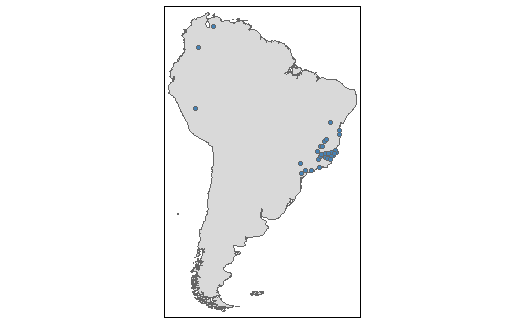

```r
# map
tm_shape(li) +
  tm_polygons() +
  tm_shape(occ_data_sptlim_date_bias_sptdist) +
  tm_dots(size = .2, shape = 21, col = "steelblue")
```

```r
occ_data_filter <- occ_data_sptlim_date_bias_sptdist
```

### Manual editing

```r
occ_data_filter_edit <- mapedit::editFeatures(occ_data_filter) # atencao para o Done!
occ_data_filter_edit

# verificar
mapview::mapview(occ_data_filter_edit)
```

### Export

```r
  # vetor
  occ_data_filter_edit %>%
  sf::st_write("03_dados/01_ocorrencias/occ_data_filter_edit.shp")
```

```
Writing layer `occ_data_filter_edit' to data source
  `03_dados/01_ocorrencias/occ_data_filter_edit.shp' using driver `ESRI Shapefile'
Writing 31 features with 7 fields and geometry type Point.
```

```r
# tabela
occ_data_filter_edit %>%
  sf::st_drop_geometry() %>%
  readr::write_csv("03_dados/01_ocorrencias/occ_data_filter_edit.csv")
```

## Variáveis ambientais

```r
# download variables
env <- worldclim_global("bio", res = 10,
                        path = "03_dados/02_variaveis")

# rename
names(env)
```

```
 [1] "wc2.1_10m_bio_1"  "wc2.1_10m_bio_2"  "wc2.1_10m_bio_3"
 [4] "wc2.1_10m_bio_4"  "wc2.1_10m_bio_5"  "wc2.1_10m_bio_6"
 [7] "wc2.1_10m_bio_7"  "wc2.1_10m_bio_8"  "wc2.1_10m_bio_9"
[10] "wc2.1_10m_bio_10" "wc2.1_10m_bio_11" "wc2.1_10m_bio_12"
[13] "wc2.1_10m_bio_13" "wc2.1_10m_bio_14" "wc2.1_10m_bio_15"
[16] "wc2.1_10m_bio_16" "wc2.1_10m_bio_17" "wc2.1_10m_bio_18"
[19] "wc2.1_10m_bio_19"
```

```r
names(env) <- paste0("bio",1:19)
names(env)
```

```
 [1] "bio1"  "bio2"  "bio3"  "bio4"  "bio5"  "bio6"  "bio7"  "bio8"
 [9] "bio9"  "bio10" "bio11" "bio12" "bio13" "bio14" "bio15" "bio16"
[17] "bio17" "bio18" "bio19"
```

```r
env
```

```
class       : SpatRaster
dimensions  : 1080, 2160, 19  (nrow, ncol, nlyr)
resolution  : 0.1666667, 0.1666667  (x, y)
extent      : -180, 180, -90, 90  (xmin, xmax, ymin, ymax)
coord. ref. : lon/lat WGS 84 (EPSG:4326)
sources     : wc2.1_10m_bio_1.tif
              wc2.1_10m_bio_2.tif
              wc2.1_10m_bio_3.tif
              ... and 16 more source(s)
names       :      bio1,     bio2,       bio3,     bio4,      bio5,      bio6, ...
min values  : -54.72435,  1.00000,   9.131122,    0.000, -29.68600, -72.50025, ...
max values  :  30.98764, 21.14754, 100.000000, 2363.846,  48.08275,  26.30000, ...
```

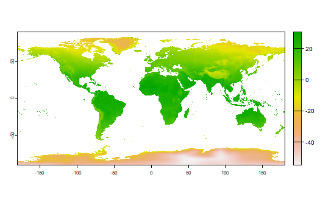

```r
# plot
plot(env$bio1)
```

### Extent and resolution

```r
# adjust extent and resolution
env_li <- env %>%
  terra::crop(li,mask = TRUE) %>%
  terra::aggregate(fact = .5/res(env)[1])
env_li
```

```
class       : SpatRaster
dimensions  : 137, 93, 19  (nrow, ncol, nlyr)
resolution  : 0.5, 0.5  (x, y)
extent      : -81.33333, -34.83333, -56, 12.5  (xmin, xmax, ymin, ymax)
coord. ref. : lon/lat WGS 84 (EPSG:4326)
source(s)   : memory
names       :      bio1,      bio2,     bio3,      bio4,      bio5,      bio6, ...
min values  : -1.873624,  4.837188, 34.38431,  16.93086,  8.660528, -11.93886, ...
max values  : 28.971971, 18.455472, 92.90907, 666.77488, 36.149694,  23.20873, ...
```

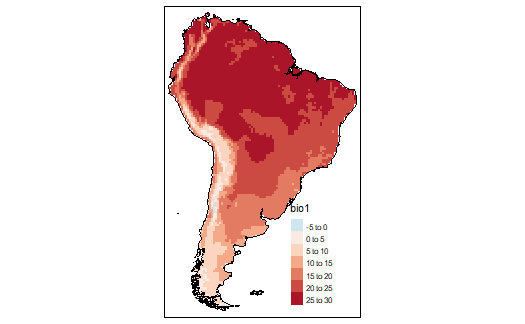

```r
# plot
tm_shape(env_li$bio1) +
  tm_raster(palette = "-RdBu", n = 10) +
  tm_shape(li) +
  tm_borders(col = "black") +
  tm_layout(legend.position = c("right", "bottom"))
```

### Collinearity

```r
# correlation
ENMTools::raster.cor.matrix(env_li, method = "pearson")
```

|  | bio1 | bio2 | bio3 | bio4 | bio5 | bio6 | bio7 | bio8 | bio9 | bio10 | bio11 | bio12 | bio13 | bio14 | bio15 | bio16 | bio17 | bio18 | bio19 |
| --- | --- | --- | --- | --- | --- | --- | --- | --- | --- | --- | --- | --- | --- | --- | --- | --- | --- | --- | --- |
| bio1 | 1.00000000 | -0.37862929 | 0.6157431 | -0.6537133 | 0.885811864 | 0.95339136 | -0.59253219 | 0.93440651 | 0.92348536 | 0.95101224 | 0.97850197 | 0.6016784 | 0.68296104 | 0.185511695 | 0.04790898 | 0.68070115 | 0.21507994 | 0.3806822 | 0.3852954 |
| bio2 | -0.37862929 | 1.00000000 | -0.3974437 | 0.5133621 | -0.066053481 | -0.59567693 | 0.80437303 | -0.21436420 | -0.52426092 | -0.26720932 | -0.44940191 | -0.6019277 | -0.52350309 | -0.522874309 | 0.42260003 | -0.52349359 | -0.54490115 | -0.2529255 | -0.5886195 |
| bio3 | 0.61574308 | -0.39744375 | 1.0000000 | -0.9124836 | 0.270143453 | 0.74444601 | -0.83816150 | 0.48155847 | 0.69433546 | 0.38107783 | 0.74072125 | 0.6317042 | 0.67938341 | 0.338823402 | 0.10930822 | 0.67233798 | 0.36170543 | 0.3512292 | 0.4858146 |
| bio4 | -0.65371330 | 0.51336211 | -0.9124836 | 1.0000000 | -0.268537952 | -0.79179138 | 0.90820106 | -0.49212121 | -0.75338660 | -0.39044308 | -0.79479904 | -0.6603764 | -0.74809537 | -0.243790172 | -0.15883385 | -0.74686800 | -0.27414896 | -0.3741578 | -0.4626327 |
| bio5 | 0.88581186 | -0.06605348 | 0.2701435 | -0.2685380 | 1.000000000 | 0.73341476 | -0.17204311 | 0.88776092 | 0.73763017 | 0.97076203 | 0.78389381 | 0.3568950 | 0.43906379 | 0.006953046 | 0.04920277 | 0.43816823 | 0.02855845 | 0.1969636 | 0.2114652 |
| bio6 | 0.95339136 | -0.59567693 | 0.7444460 | -0.7917914 | 0.733414757 | 1.00000000 | -0.79582446 | 0.82860217 | 0.95834864 | 0.84419701 | 0.98111097 | 0.7107690 | 0.76892403 | 0.310303768 | -0.03552147 | 0.76581226 | 0.34333765 | 0.3764318 | 0.5373146 |
| bio7 | -0.59253219 | 0.80437303 | -0.8381615 | 0.9082011 | -0.172043115 | -0.79582446 | 1.00000000 | -0.40996069 | -0.73171140 | -0.35862487 | -0.72348675 | -0.7120838 | -0.72316447 | -0.443475926 | 0.09530335 | -0.71945284 | -0.47210081 | -0.3700486 | -0.5902705 |
| bio8 | 0.93440651 | -0.21436420 | 0.4815585 | -0.4921212 | 0.887760920 | 0.82860217 | -0.40996069 | 1.00000000 | 0.73854469 | 0.93210462 | 0.87960941 | 0.4815507 | 0.54895565 | 0.131202512 | 0.07945073 | 0.54589706 | 0.15516997 | 0.4054360 | 0.2362239 |
| bio9 | 0.92348536 | -0.52426092 | 0.6943355 | -0.7533866 | 0.737630172 | 0.95834864 | -0.73171140 | 0.73854469 | 1.00000000 | 0.82321429 | 0.94702571 | 0.6557743 | 0.73652896 | 0.234457910 | 0.01378883 | 0.73502604 | 0.26623333 | 0.2933783 | 0.5136476 |
| bio10 | 0.95101224 | -0.26720932 | 0.3810778 | -0.3904431 | 0.970762034 | 0.84419701 | -0.35862487 | 0.93210462 | 0.82321429 | 1.00000000 | 0.86888117 | 0.4725052 | 0.53322393 | 0.134719086 | -0.01954393 | 0.53091573 | 0.15900653 | 0.2965053 | 0.3007796 |

[output cut: 9 more lines]

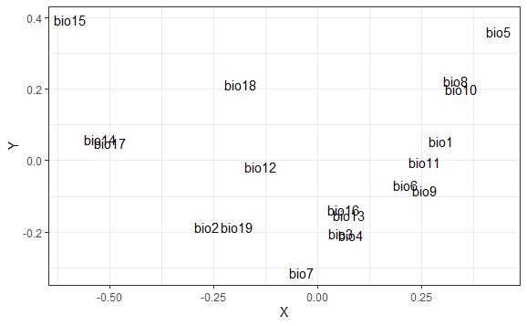

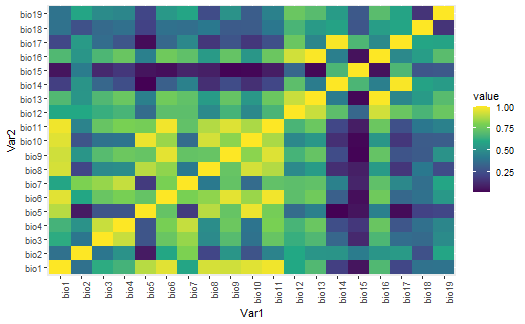

```r
ENMTools::raster.cor.plot(env_li)
```

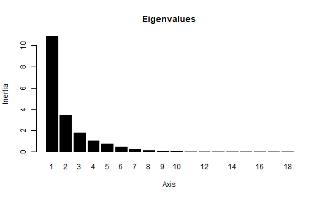

```r
# pca
env_li_pca <- ade4::dudi.pca(env_li, center = TRUE,
                             scale = TRUE, scannf = FALSE,
                             nf = nlyr(env_li))
screeplot(env_li_pca, main = "Eigenvalues")
```

```r
# The cumulative % of variance explained by each component ;
k = 100 * env_li_pca$eig/sum(env_li_pca$eig)
cumsum(k)
```

```
 [1]  57.34506  75.55380  84.98207  90.45982  94.55837  97.05559
 [7]  98.28217  99.04330  99.52055  99.79197  99.87001  99.92737
[13]  99.95595  99.97618  99.98781  99.99830  99.99974 100.00000
```

```r
env_li_pca <- env_li_pca$li[,1:5]

# vif
env_li_vif <- usdm::vif(env_li)
env_li_vif
```

| Variables | VIF |
| --- | --- |
| bio1 | 2.728446e+03 |
| bio2 | 7.078830e+01 |
| bio3 | 2.985439e+01 |
| bio4 | 2.996246e+03 |
| bio5 | 1.125900e+15 |
| bio6 | 3.002400e+15 |
| bio7 | 1.501200e+15 |
| bio8 | 4.706172e+01 |
| bio9 | 5.060636e+01 |
| bio10 | 4.404113e+03 |

[output cut: 9 more lines]

```r
# vifstep
env_li_vifstep <- usdm::vifstep(env_li, th = 2)
env_li_vifstep
```

```
13 variables from the 19 input variables have collinearity problem:

bio6 bio11 bio10 bio1 bio7 bio16 bio17 bio12 bio5 bio4 bio13 bio9 bio14

After excluding the collinear variables, the linear correlation coefficients ranges between:
min correlation ( bio15 ~ bio8 ):  0.07110001
max correlation ( bio19 ~ bio2 ):  -0.5901968

---------- VIFs of the remained variables --------
```

| Variables | VIF |
| --- | --- |
| bio2 | 1.874628 |
| bio3 | 1.987136 |
| bio8 | 1.452726 |
| bio15 | 1.636619 |
| bio18 | 1.480171 |
| bio19 | 1.838319 |

```r
# vifcor
env_li_vifcor <- usdm::vifcor(env_li, th = .7)
env_li_vifcor
```

```
11 variables from the 19 input variables have collinearity problem:

bio16 bio17 bio6 bio11 bio10 bio1 bio4 bio12 bio5 bio7 bio9

After excluding the collinear variables, the linear correlation coefficients ranges between:
min correlation ( bio15 ~ bio13 ):  -0.0240551
max correlation ( bio19 ~ bio13 ):  0.6983483

---------- VIFs of the remained variables --------
```

| Variables | VIF |
| --- | --- |
| bio2 | 2.006824 |
| bio3 | 2.234972 |
| bio8 | 1.621314 |
| bio13 | 6.227132 |
| bio14 | 4.551635 |
| bio15 | 2.765042 |
| bio18 | 3.723900 |
| bio19 | 4.598492 |

```r
# select
env_li_vif <- usdm::exclude(env_li, env_li_vifstep)
env_li_vif
```

```
class       : SpatRaster
dimensions  : 137, 93, 6  (nrow, ncol, nlyr)
resolution  : 0.5, 0.5  (x, y)
extent      : -81.33333, -34.83333, -56, 12.5  (xmin, xmax, ymin, ymax)
coord. ref. : lon/lat WGS 84 (EPSG:4326)
source(s)   : memory
names       :      bio2,     bio3,      bio8,    bio15,    bio18,    bio19
min values  :  4.837188, 34.38431, -6.101616,   0.0000,    0.000,    0.000
max values  : 18.455472, 92.90907, 28.959958, 177.5217, 1564.778, 1970.333
```

```r
env_li_cor <- usdm::exclude(env_li, env_li_vifcor)
env_li_cor
```

```
class       : SpatRaster
dimensions  : 137, 93, 8  (nrow, ncol, nlyr)
resolution  : 0.5, 0.5  (x, y)
extent      : -81.33333, -34.83333, -56, 12.5  (xmin, xmax, ymin, ymax)
coord. ref. : lon/lat WGS 84 (EPSG:4326)
source(s)   : memory
names       :      bio2,     bio3,      bio8,    bio13, bio14,    bio15, ...
min values  :  4.837188, 34.38431, -6.101616,   0.0000,     0,   0.0000, ...
max values  : 18.455472, 92.90907, 28.959958, 735.6667,   445, 177.5217, ...
```

### Scale

```r
env_li_vif_scale <- terra::scale(env_li_vif)
env_li_vif_scale
```

```
class       : SpatRaster
dimensions  : 137, 93, 6  (nrow, ncol, nlyr)
resolution  : 0.5, 0.5  (x, y)
extent      : -81.33333, -34.83333, -56, 12.5  (xmin, xmax, ymin, ymax)
coord. ref. : lon/lat WGS 84 (EPSG:4326)
source(s)   : memory
names       :      bio2,      bio3,      bio8,     bio15,     bio18,     bio19
min values  : -3.022951, -2.553895, -4.107773, -2.165754, -1.710690, -0.942845
max values  :  3.368859,  1.879449,  1.047039,  4.462554,  5.820596,  4.671886
```

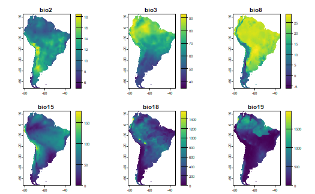

```r
# plot
plot(env_li_vif, col = viridis::viridis(100))
```

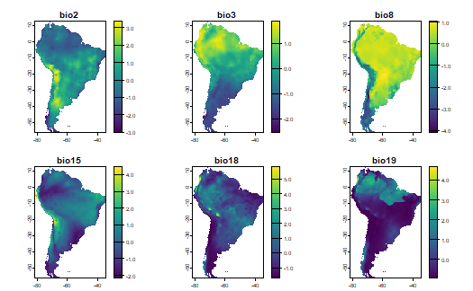

```r
plot(env_li_vif_scale, col = viridis::viridis(100))
```

### Export

```r
terra::writeRaster(x = env_li_vif_scale,
                    filename = paste0("03_dados/02_variaveis/", names(env_li_vif_scale),
                     ".tif"),
                    overwrite = TRUE)
```

# Ambiente marinho

Primeiro vamos criar um shape file para a Zona FAO 41

```r
path_sf <- here("data/espacial/fao_areas")

# The File
name_sf <- "FAO_AREAS_CWP.shp"

# Load it!
li <- st_read(dsn = path_sf,
              layer = tools::file_path_sans_ext(name_sf))

# filter FAO zona 41
li <- li %>%
  filter(F_AREA == "41") %>%
  st_union

tm_shape(li) +
  tm_polygons()
```

## Ocorrencia

Vamos baixar ocorrencias para a espécie de sardinha *Opisthonema oglinum*.

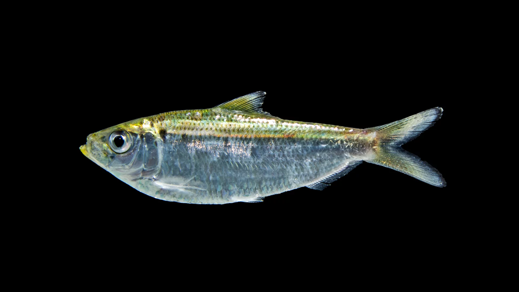

```r
sp <- "Opisthonema oglinum"

# spocc - pode demorar um tempo...
occ_spocc <- spocc::occ(query = sp,
                        from = c("gbif", "inat", "vertnet", "idigbio"),
                        has_coords = TRUE,
                        limit = 1e4)
occ_spocc


# Tambem vamos baixar dados de ocorrencia da OBIS, uma base dados dedicada a espécies marinhas.
occ_obis <- robis::occurrence(scientificname = sp)
occ_obis

# get data
occ_spocc_data <- spocc::occ2df(occ_spocc) %>%
  dplyr::mutate(species = sp,
                longitude = as.numeric(longitude),
                latitude = as.numeric(latitude),
                year = date %>% lubridate::year()) %>%
  dplyr::select(species, longitude, latitude, year)

occ_spocc_data

occ_obis_data <- occ_obis %>%
  dplyr::mutate(species = species,
                longitude = as.numeric(decimalLongitude),
                latitude = as.numeric(decimalLatitude),
                year = date_year) %>%
  dplyr::select(species, longitude, latitude, year)

occ_obis_data

# combine data
occ_data <- dplyr::bind_rows(occ_spocc_data, occ_obis_data)
occ_data

# map
occ_data_vector <- occ_data %>%
  tidyr::drop_na(longitude, latitude) %>%
  dplyr::mutate(lon = longitude, lat = latitude) %>%
  dplyr::filter(lon >= -180, lon <= 180, lat >= -90, lat <= 90) %>%
  sf::st_as_sf(coords = c("lon", "lat"), crs = 4326)

occ_data_vector

tm_shape(li, bbox = occ_data_vector) +
  tm_polygons() +
  tm_shape(occ_data_vector) +
  tm_dots(size = .2, shape = 21, col = "steelblue") +
  tm_graticules(lines = FALSE)
```

### Spatial limit filter

```r
# crop to limit
occ_data_sptlim <- occ_data_vector %>%
  st_crop(li)

occ_data_sptlim

# map
tm_shape(li) +
  tm_polygons() +
  tm_shape(occ_data_sptlim) +
  tm_dots(size = .2, shape = 21, col = "steelblue")
```

### Date filter

```r
# verify
hist(occ_data_sptlim$year)

# year > 1970 and < 2021
occ_data_sptlim_date <- occ_data_sptlim %>%
  filter(year >= 1970)
occ_data_sptlim_date

# map
tm_shape(li) +
  tm_polygons() +
  tm_shape(occ_data_sptlim_date) +
  tm_dots(size = .2, shape = 21, col = "steelblue")
```

### Bias filter

Note que removi o teste para coordenadas dentro do oceano…

```r
# flag data
occ_data_sptlim_date_bias <- CoordinateCleaner::clean_coordinates(
  x = sf::st_drop_geometry(occ_data_sptlim_date),
  species = "species",
  lon = "longitude",
  lat = "latitude",
  outliers_mtp = 2,
  value = "clean", # return the clean dataset
  tests = c("capitals", # radius around capitals
            "centroids", # radius around country and province centroids
            "duplicates", # records from one species with identical coordinates
            "equal", # equal coordinates
            "gbif", # radius around GBIF headquarters
            "institutions", # radius around biodiversity institutions
            # "seas", # in the sea
            "urban", # within urban area
            "validity", # outside reference coordinate system
            "zeros" # plain zeros and lat = lon
  )) %>%
  tibble::as_tibble() %>%
  dplyr::mutate(lon = longitude, lat = latitude) %>%
  sf::st_as_sf(coords = c("lon", "lat"), crs = 4326)
occ_data_sptlim_date_bias

# map
tm_shape(li) +
  tm_polygons() +
  tm_shape(occ_data_sptlim_date_bias) +
  tm_dots(size = .2, shape = 21, col = "steelblue")
```

### Spatial distance filter

```r
filter_thin <- spThin::thin(loc.data = occ_data_sptlim_date_bias,
                            lat.col = "latitude",
                            long.col = "longitude",
                            spec.col = "species",
                            thin.par = 50,
                            reps = 1,
                            write.files = FALSE,
                            write.log.file = FALSE,
                            locs.thinned.list.return = TRUE,
                            verbose = TRUE) %>%
  .[[1]] %>%
  tibble::as_tibble() %>%
  dplyr::rename_with(tolower) %>%
  dplyr::mutate(sptdist_filter = TRUE)
filter_thin

# join
occ_data_sptlim_date_bias_sptdist <- dplyr::left_join(
  x = occ_data_sptlim_date_bias,
  y = filter_thin,
  by = c("longitude", "latitude")) %>%
  filter(sptdist_filter)
occ_data_sptlim_date_bias_sptdist

# map
tm_shape(li) +
  tm_polygons() +
  tm_shape(occ_data_sptlim_date_bias_sptdist) +
  tm_dots(size = .2, shape = 21, col = "steelblue")

occ_data_filter <- occ_data_sptlim_date_bias_sptdist
```

### Manual editing

```r
occ_data_filter_edit <- mapedit::editFeatures(occ_data_filter) # atencao para o Done!
occ_data_filter_edit

# verificar
mapview::mapview(occ_data_filter_edit)
```

### Export

```r
----
  # vetor
  occ_data_filter_edit %>%
  sf::st_write("03_dados/01_ocorrencias/occ_data_filter_edit.shp")

# tabela
occ_data_filter_edit %>%
  sf::st_drop_geometry() %>%
  readr::write_csv("03_dados/01_ocorrencias/occ_data_filter_edit.csv")
```

## Variáveis ambientais

Para o ambiente marinho, vamos usar o pacote SDMpredictors

```r
env_datasets <- list_datasets(terrestrial = FALSE, marine = TRUE)
env_datasets %>%
  dplyr::select(dataset_code, description, citation)

env_datasets_vec <- c("Bio-ORACLE", "MARSPEC")
env_layers <- sdmpredictors::list_layers(env_datasets_vec)

env_layers_select <- c(
  "BO_bathymean", # Bathymetry
  "BO2_tempmean_ss", # Sea surface temperature
  "BO2_chlomean_ss", # Chlorophyll concentration
  "BO2_salinitymean_ss", # Salinity
  "BO21_nitratemean_ss", # Nitrate concentration
  "MS_biogeo05_dist_shore_5m", # Distance to shore
  "MS_biogeo13_sst_mean_5m", # Mean annual temperature
  "BO22_parmean", # Solar radiation
  "BO22_damean", # Turbidity
  "BO2_dissoxmean_bdmean" # Oxygen concentration
)


# download variables
env <- lapply(env_layers_select, function(x)
  rast(load_layers(x, datadir = "data"))
)
env <- rast(env)

# plot
plot(env$BO_bathymean)
```

Estas variáveis bioclimáticas estão em uma resolução de 0.08 degrees, que seria equivalente a 10km x 10km

### Extent and resolution

Se acharmos que a resolução de 10km x 10km é muito fina, podemos reduzir a resolução desse raster. Aqui vamos reduzir a resolução das variáveis bioclimáticas para 1/2 degree (~50km x 50km)

```r
# adjust extent and resolution
env_li <- env %>%
  terra::crop(li,mask = TRUE) %>%
  terra::aggregate(fact = .5/res(env)[1])
env_li

# plot
tm_shape(env_li$BO_bathymean) +
  tm_raster(palette = "-RdBu", n = 10) +
  tm_shape(li) +
  tm_borders(col = "black") +
  tm_layout(legend.position = c("right", "bottom"))
```

### Collinearity

```r
# correlation
ENMTools::raster.cor.matrix(env_li, method = "pearson")
ENMTools::raster.cor.plot(env_li)

# pca
env_li_pca_model <- ade4::dudi.pca(na.omit(data.frame(env_li)), center = TRUE,
                                   scale = TRUE, scannf = FALSE,
                                   nf = nlyr(env_li))
screeplot(env_li_pca_model, main = "Eigenvalues")
# The cumulative % of variance explained by each component ;
k = 100 * env_li_pca_model$eig/sum(env_li_pca_model$eig)
cumsum(k)

env_li_pca_preds <- predict(env_li_pca_model,data.frame(env_li))
tmp_rast <- env_li[[1]]
env_li_pca <- lapply(1:5, function(x){
  setValues(tmp_rast, env_li_pca_preds[,x])
})
env_li_pca <- rast(env_li_pca)
names(env_li_pca) <- paste0("Axis", 1:5)

# vif
env_li_vif <- usdm::vif(env_li)
env_li_vif

# vifstep
env_li_vifstep <- usdm::vifstep(env_li, th = 2)
env_li_vifstep

# vifcor
env_li_vifcor <- usdm::vifcor(env_li, th = .7)
env_li_vifcor

# select
env_li_vif <- usdm::exclude(env_li, env_li_vifstep)
env_li_vif

env_li_cor <- usdm::exclude(env_li, env_li_vifcor)
env_li_cor
```

### Scale

```r
env_li_vif_scale <- terra::scale(env_li_vif)
env_li_vif_scale

# plot
plot(env_li_vif, col = viridis::viridis(100))
plot(env_li_vif_scale, col = viridis::viridis(100))
```

### Export

```r
raster::writeRaster(x = env_li_vif_scale,
                    filename = paste0("03_dados/02_variaveis/", names(env_li_vif_scale)),
                    bylayer = TRUE,
                    format = "GTiff",
                    overwrite = TRUE)
```